# AdvancedML_Anusha

### Surprise House Price Prediction

- By Oorugonda Anusha

### Problem Statement

A US-based housing company named Surprise Housing has decided to enter the Australian market. The company uses data analytics to purchase houses at a price below their actual values and flip them on at a higher price.

**The company wants to know**:

- Which variables are significant in predicting the price of a house, and
- How well those variables describe the price of a house.

**Business Goal**

- Need to create model based on the price of houses with the available independent variables.
- This model will then be used by the management to understand how exactly the prices vary with the variables.
- They can accordingly manipulate the strategy of the firm and concentrate on areas that will yield high returns.
- Further, the model will be a good way for management to understand the pricing dynamics of a new market.
- determine the optimal value of lambda for ridge and lasso regression.
- find the top most influencing parameters which describes the price of the house and yield more returns

```python
# To Supress Warnings
import warnings
warnings.filterwarnings('ignore')
import sys
import os
import warnings
import pandas as pd
import numpy as np
import matplotlib.pyplot as plt
import seaborn as sns
from sklearn.preprocessing import StandardScaler,MinMaxScaler
from sklearn.model_selection import train_test_split,GridSearchCV,KFold,cross_val_score
from sklearn.linear_model import LinearRegression,Ridge,Lasso
from sklearn.feature_selection import RFE
from sklearn.metrics import r2_score
%matplotlib inline
```

```python
# To display all the columns
pd.options.display.max_columns = None

# To display all the rows
pd.options.display.max_rows = None

# To map Empty Strings or numpy.inf as Na Values
pd.options.mode.use_inf_as_na = True

# Set Precision to 8 for better readability
pd.set_option('precision', 8)
pd.options.display.float_format = '{:.4f}'.format

pd.options.display.expand_frame_repr =  False

%matplotlib inline

# Set Style
sns.set(style = "whitegrid")

# Ignore Warnings
warnings.filterwarnings('ignore')
```

### Step 1: Reading and Understanding the Data

```python
#Import the data - read the csv file and view the data.please check the folder path while importing
housing_price = pd.read_csv(r'D:\IIITB Docs\train.csv')
housing_price.head()
```

|  | Id | MSSubClass | MSZoning | LotFrontage | LotArea | Street | Alley | LotShape | LandContour | Utilities | LotConfig | LandSlope | Neighborhood | Condition1 | Condition2 | BldgType | HouseStyle | OverallQual | OverallCond | YearBuilt | YearRemodAdd | RoofStyle | RoofMatl | Exterior1st | Exterior2nd | MasVnrType | MasVnrArea | ExterQual | ExterCond | … |
| --- | --- | --- | --- | --- | --- | --- | --- | --- | --- | --- | --- | --- | --- | --- | --- | --- | --- | --- | --- | --- | --- | --- | --- | --- | --- | --- | --- | --- | --- | --- |
| 0 | 1 | 60 | RL | 65.0000 | 8450 | Pave | NaN | Reg | Lvl | AllPub | Inside | Gtl | CollgCr | Norm | Norm | 1Fam | 2Story | 7 | 5 | 2003 | 2003 | Gable | CompShg | VinylSd | VinylSd | BrkFace | 196.0000 | Gd | TA | … |
| 1 | 2 | 20 | RL | 80.0000 | 9600 | Pave | NaN | Reg | Lvl | AllPub | FR2 | Gtl | Veenker | Feedr | Norm | 1Fam | 1Story | 6 | 8 | 1976 | 1976 | Gable | CompShg | MetalSd | MetalSd | None | 0.0000 | TA | TA | … |
| 2 | 3 | 60 | RL | 68.0000 | 11250 | Pave | NaN | IR1 | Lvl | AllPub | Inside | Gtl | CollgCr | Norm | Norm | 1Fam | 2Story | 7 | 5 | 2001 | 2002 | Gable | CompShg | VinylSd | VinylSd | BrkFace | 162.0000 | Gd | TA | … |
| 3 | 4 | 70 | RL | 60.0000 | 9550 | Pave | NaN | IR1 | Lvl | AllPub | Corner | Gtl | Crawfor | Norm | Norm | 1Fam | 2Story | 7 | 5 | 1915 | 1970 | Gable | CompShg | Wd Sdng | Wd Shng | None | 0.0000 | TA | TA | … |
| 4 | 5 | 60 | RL | 84.0000 | 14260 | Pave | NaN | IR1 | Lvl | AllPub | FR2 | Gtl | NoRidge | Norm | Norm | 1Fam | 2Story | 8 | 5 | 2000 | 2000 | Gable | CompShg | VinylSd | VinylSd | BrkFace | 350.0000 | Gd | TA | … |

```python
housing_price.shape
```

```
(1460, 81)
```

```python
housing_price.info()
```

```
<class 'pandas.core.frame.DataFrame'>
RangeIndex: 1460 entries, 0 to 1459
Data columns (total 81 columns):
 #   Column         Non-Null Count  Dtype
---  ------         --------------  -----
 0   Id             1460 non-null   int64
 1   MSSubClass     1460 non-null   int64
 2   MSZoning       1460 non-null   object
 3   LotFrontage    1201 non-null   float64
 4   LotArea        1460 non-null   int64
 5   Street         1460 non-null   object
 6   Alley          91 non-null     object
 7   LotShape       1460 non-null   object
 8   LandContour    1460 non-null   object
 9   Utilities      1460 non-null   object
```

[output cut: 73 more lines]

```python
housing_price.describe([0.25,0.50,0.75,0.99])
```

|  | Id | MSSubClass | LotFrontage | LotArea | OverallQual | OverallCond | YearBuilt | YearRemodAdd | MasVnrArea | BsmtFinSF1 | BsmtFinSF2 | BsmtUnfSF | TotalBsmtSF | 1stFlrSF | 2ndFlrSF | LowQualFinSF | GrLivArea | BsmtFullBath | BsmtHalfBath | FullBath | HalfBath | BedroomAbvGr | KitchenAbvGr | TotRmsAbvGrd | Fireplaces | GarageYrBlt | GarageCars | GarageArea | WoodDeckSF | … |
| --- | --- | --- | --- | --- | --- | --- | --- | --- | --- | --- | --- | --- | --- | --- | --- | --- | --- | --- | --- | --- | --- | --- | --- | --- | --- | --- | --- | --- | --- | --- |
| count | 1460.0000 | 1460.0000 | 1201.0000 | 1460.0000 | 1460.0000 | 1460.0000 | 1460.0000 | 1460.0000 | 1452.0000 | 1460.0000 | 1460.0000 | 1460.0000 | 1460.0000 | 1460.0000 | 1460.0000 | 1460.0000 | 1460.0000 | 1460.0000 | 1460.0000 | 1460.0000 | 1460.0000 | 1460.0000 | 1460.0000 | 1460.0000 | 1460.0000 | 1379.0000 | 1460.0000 | 1460.0000 | 1460.0000 | … |
| mean | 730.5000 | 56.8973 | 70.0500 | 10516.8281 | 6.0993 | 5.5753 | 1971.2678 | 1984.8658 | 103.6853 | 443.6397 | 46.5493 | 567.2404 | 1057.4295 | 1162.6267 | 346.9925 | 5.8445 | 1515.4637 | 0.4253 | 0.0575 | 1.5651 | 0.3829 | 2.8664 | 1.0466 | 6.5178 | 0.6130 | 1978.5062 | 1.7671 | 472.9801 | 94.2445 | … |
| std | 421.6100 | 42.3006 | 24.2848 | 9981.2649 | 1.3830 | 1.1128 | 30.2029 | 20.6454 | 181.0662 | 456.0981 | 161.3193 | 441.8670 | 438.7053 | 386.5877 | 436.5284 | 48.6231 | 525.4804 | 0.5189 | 0.2388 | 0.5509 | 0.5029 | 0.8158 | 0.2203 | 1.6254 | 0.6447 | 24.6897 | 0.7473 | 213.8048 | 125.3388 | … |
| min | 1.0000 | 20.0000 | 21.0000 | 1300.0000 | 1.0000 | 1.0000 | 1872.0000 | 1950.0000 | 0.0000 | 0.0000 | 0.0000 | 0.0000 | 0.0000 | 334.0000 | 0.0000 | 0.0000 | 334.0000 | 0.0000 | 0.0000 | 0.0000 | 0.0000 | 0.0000 | 0.0000 | 2.0000 | 0.0000 | 1900.0000 | 0.0000 | 0.0000 | 0.0000 | … |
| 25% | 365.7500 | 20.0000 | 59.0000 | 7553.5000 | 5.0000 | 5.0000 | 1954.0000 | 1967.0000 | 0.0000 | 0.0000 | 0.0000 | 223.0000 | 795.7500 | 882.0000 | 0.0000 | 0.0000 | 1129.5000 | 0.0000 | 0.0000 | 1.0000 | 0.0000 | 2.0000 | 1.0000 | 5.0000 | 0.0000 | 1961.0000 | 1.0000 | 334.5000 | 0.0000 | … |
| 50% | 730.5000 | 50.0000 | 69.0000 | 9478.5000 | 6.0000 | 5.0000 | 1973.0000 | 1994.0000 | 0.0000 | 383.5000 | 0.0000 | 477.5000 | 991.5000 | 1087.0000 | 0.0000 | 0.0000 | 1464.0000 | 0.0000 | 0.0000 | 2.0000 | 0.0000 | 3.0000 | 1.0000 | 6.0000 | 1.0000 | 1980.0000 | 2.0000 | 480.0000 | 0.0000 | … |
| 75% | 1095.2500 | 70.0000 | 80.0000 | 11601.5000 | 7.0000 | 6.0000 | 2000.0000 | 2004.0000 | 166.0000 | 712.2500 | 0.0000 | 808.0000 | 1298.2500 | 1391.2500 | 728.0000 | 0.0000 | 1776.7500 | 1.0000 | 0.0000 | 2.0000 | 1.0000 | 3.0000 | 1.0000 | 7.0000 | 1.0000 | 2002.0000 | 2.0000 | 576.0000 | 168.0000 | … |
| 99% | 1445.4100 | 190.0000 | 141.0000 | 37567.6400 | 10.0000 | 9.0000 | 2009.0000 | 2009.0000 | 791.9200 | 1572.4100 | 830.3800 | 1797.0500 | 2155.0500 | 2219.4600 | 1418.9200 | 360.0000 | 3123.4800 | 2.0000 | 1.0000 | 3.0000 | 1.0000 | 5.0000 | 2.0000 | 11.0000 | 2.0000 | 2009.0000 | 3.0000 | 1002.7900 | 505.4600 | … |
| max | 1460.0000 | 190.0000 | 313.0000 | 215245.0000 | 10.0000 | 9.0000 | 2010.0000 | 2010.0000 | 1600.0000 | 5644.0000 | 1474.0000 | 2336.0000 | 6110.0000 | 4692.0000 | 2065.0000 | 572.0000 | 5642.0000 | 3.0000 | 2.0000 | 3.0000 | 2.0000 | 8.0000 | 3.0000 | 14.0000 | 3.0000 | 2010.0000 | 4.0000 | 1418.0000 | 857.0000 | … |

```python
housing_price.isnull().any()
```

```
Id               False
MSSubClass       False
MSZoning         False
LotFrontage       True
LotArea          False
Street           False
Alley             True
LotShape         False
LandContour      False
Utilities        False
LotConfig        False
LandSlope        False
Neighborhood     False
Condition1       False
Condition2       False
BldgType         False
HouseStyle       False
OverallQual      False
OverallCond      False
YearBuilt        False
YearRemodAdd     False
RoofStyle        False
RoofMatl         False
Exterior1st      False
Exterior2nd      False
MasVnrType        True
MasVnrArea        True
ExterQual        False
ExterCond        False
Foundation       False
BsmtQual          True
BsmtCond          True
BsmtExposure      True
BsmtFinType1      True
BsmtFinSF1       False
BsmtFinType2      True
BsmtFinSF2       False
BsmtUnfSF        False
TotalBsmtSF      False
Heating          False
```

[output cut: 27 more lines]

```
OpenPorchSF      False
EnclosedPorch    False
3SsnPorch        False
ScreenPorch      False
PoolArea         False
PoolQC            True
Fence             True
MiscFeature       True
MiscVal          False
MoSold           False
YrSold           False
SaleType         False
SaleCondition    False
SalePrice        False
dtype: bool
```

### Step 2: Data Cleaning

Lets have a look at the missing values

```python
missing=round(housing_price.isnull().sum()/len(housing_price.index),2).sort_values(ascending=False)
missing.loc[missing>0]
```

```
PoolQC         1.0000
MiscFeature    0.9600
Alley          0.9400
Fence          0.8100
FireplaceQu    0.4700
LotFrontage    0.1800
GarageType     0.0600
GarageCond     0.0600
GarageYrBlt    0.0600
GarageFinish   0.0600
GarageQual     0.0600
BsmtFinType1   0.0300
BsmtExposure   0.0300
BsmtCond       0.0300
BsmtQual       0.0300
BsmtFinType2   0.0300
MasVnrArea     0.0100
MasVnrType     0.0100
dtype: float64
```

Remove the null values which are above 45%,There are columns which has 100% of missing values, they don't have any use in the analysis, so dropping the columns which are having 45% and above missing values

```python
missing_columns=list(missing[missing >=0.45].index)
print(len(missing_columns))
print(missing_columns)
```

```
5
['PoolQC', 'MiscFeature', 'Alley', 'Fence', 'FireplaceQu']
```

```python
#dropping Id as it has no contribution in Analysis along with the columns having missing values
housing_price=housing_price.drop(missing_columns,axis=1)
housing_price=housing_price.drop(['LotFrontage','Id'],axis=1)
```

```python
housing_price.shape
```

```
(1460, 74)
```

```python
#Lets check the missing values again
missing=round(housing_price.isnull().sum()/len(housing_price.index),2).sort_values(ascending=False)
missing.loc[missing>0]
```

```
GarageType     0.0600
GarageCond     0.0600
GarageYrBlt    0.0600
GarageFinish   0.0600
GarageQual     0.0600
BsmtFinType1   0.0300
BsmtExposure   0.0300
BsmtCond       0.0300
BsmtQual       0.0300
BsmtFinType2   0.0300
MasVnrArea     0.0100
MasVnrType     0.0100
dtype: float64
```

**Deriving New columns from the year columns**

Let us convert the Year columns with the age where we are going to fill these columns with number,And if we find the max year for all these columns these will come out to be 2010 ,for example Then YearBuiltOld = 2010-2000 =10

```python
housing_price['YearBuilt_Old'] = housing_price.YearBuilt.max()-housing_price.YearBuilt
housing_price['YearRemodAdd_Old'] = housing_price.YearRemodAdd.max()-housing_price.YearRemodAdd
housing_price['GarageYrBlt_Old'] = housing_price.GarageYrBlt.max()-housing_price.GarageYrBlt
housing_price['YrSold_Old'] = housing_price.YrSold.max()-housing_price.YrSold
housing_price[['YearBuilt','YearRemodAdd','GarageYrBlt','YrSold','YearBuilt_Old','YearRemodAdd_Old',
             'GarageYrBlt_Old','YrSold_Old']].head()
```

|  | YearBuilt | YearRemodAdd | GarageYrBlt | YrSold | YearBuilt_Old | YearRemodAdd_Old | GarageYrBlt_Old | YrSold_Old |
| --- | --- | --- | --- | --- | --- | --- | --- | --- |
| 0 | 2003 | 2003 | 2003.0000 | 2008 | 7 | 7 | 7.0000 | 2 |
| 1 | 1976 | 1976 | 1976.0000 | 2007 | 34 | 34 | 34.0000 | 3 |
| 2 | 2001 | 2002 | 2001.0000 | 2008 | 9 | 8 | 9.0000 | 2 |
| 3 | 1915 | 1970 | 1998.0000 | 2006 | 95 | 40 | 12.0000 | 4 |
| 4 | 2000 | 2000 | 2000.0000 | 2008 | 10 | 10 | 10.0000 | 2 |

As the information of year columns present in Age, So dropping them

```python
#dropping the MoSold column as we need year
housing_price = housing_price.drop(['YearBuilt','YearRemodAdd','GarageYrBlt','YrSold','MoSold'],axis='columns')
```

**Imputing the Missing Values**  
Lets impute the above missing values

```python
#imputing GarageYrBlt_Old=-1 for no garrages
housing_price.MasVnrType.fillna('None',inplace=True)
housing_price.MasVnrArea.fillna(housing_price.MasVnrArea.mean(),inplace=True)
housing_price.BsmtQual.fillna('TA',inplace=True)
housing_price.BsmtCond.fillna('TA',inplace=True)
housing_price.BsmtExposure.fillna('No',inplace=True)
housing_price.BsmtFinType1.fillna('Unf',inplace=True)
housing_price.BsmtFinType2.fillna('Unf',inplace=True)
housing_price.GarageType.fillna('Attchd',inplace=True)
housing_price.GarageYrBlt_Old.fillna(-1,inplace=True)
housing_price.GarageFinish.fillna('Unf',inplace=True)
housing_price.GarageQual.fillna('TA',inplace=True)
housing_price.GarageCond.fillna('TA',inplace=True)
```

```python
catagorical_cols=list(housing_price.dtypes[housing_price.dtypes=='object'].index)
for i in catagorical_cols:
    print(i, housing_price[i].unique())
```

```
MSZoning ['RL' 'RM' 'C (all)' 'FV' 'RH']
Street ['Pave' 'Grvl']
LotShape ['Reg' 'IR1' 'IR2' 'IR3']
LandContour ['Lvl' 'Bnk' 'Low' 'HLS']
Utilities ['AllPub' 'NoSeWa']
LotConfig ['Inside' 'FR2' 'Corner' 'CulDSac' 'FR3']
LandSlope ['Gtl' 'Mod' 'Sev']
Neighborhood ['CollgCr' 'Veenker' 'Crawfor' 'NoRidge' 'Mitchel' 'Somerst' 'NWAmes'
 'OldTown' 'BrkSide' 'Sawyer' 'NridgHt' 'NAmes' 'SawyerW' 'IDOTRR'
 'MeadowV' 'Edwards' 'Timber' 'Gilbert' 'StoneBr' 'ClearCr' 'NPkVill'
 'Blmngtn' 'BrDale' 'SWISU' 'Blueste']
Condition1 ['Norm' 'Feedr' 'PosN' 'Artery' 'RRAe' 'RRNn' 'RRAn' 'PosA' 'RRNe']
Condition2 ['Norm' 'Artery' 'RRNn' 'Feedr' 'PosN' 'PosA' 'RRAn' 'RRAe']
BldgType ['1Fam' '2fmCon' 'Duplex' 'TwnhsE' 'Twnhs']
HouseStyle ['2Story' '1Story' '1.5Fin' '1.5Unf' 'SFoyer' 'SLvl' '2.5Unf' '2.5Fin']
RoofStyle ['Gable' 'Hip' 'Gambrel' 'Mansard' 'Flat' 'Shed']
RoofMatl ['CompShg' 'WdShngl' 'Metal' 'WdShake' 'Membran' 'Tar&Grv' 'Roll'
 'ClyTile']
Exterior1st ['VinylSd' 'MetalSd' 'Wd Sdng' 'HdBoard' 'BrkFace' 'WdShing' 'CemntBd'
 'Plywood' 'AsbShng' 'Stucco' 'BrkComm' 'AsphShn' 'Stone' 'ImStucc'
 'CBlock']
Exterior2nd ['VinylSd' 'MetalSd' 'Wd Shng' 'HdBoard' 'Plywood' 'Wd Sdng' 'CmentBd'
 'BrkFace' 'Stucco' 'AsbShng' 'Brk Cmn' 'ImStucc' 'AsphShn' 'Stone'
 'Other' 'CBlock']
MasVnrType ['BrkFace' 'None' 'Stone' 'BrkCmn']
ExterQual ['Gd' 'TA' 'Ex' 'Fa']
ExterCond ['TA' 'Gd' 'Fa' 'Po' 'Ex']
Foundation ['PConc' 'CBlock' 'BrkTil' 'Wood' 'Slab' 'Stone']
BsmtQual ['Gd' 'TA' 'Ex' 'Fa']
BsmtCond ['TA' 'Gd' 'Fa' 'Po']
BsmtExposure ['No' 'Gd' 'Mn' 'Av']
BsmtFinType1 ['GLQ' 'ALQ' 'Unf' 'Rec' 'BLQ' 'LwQ']
BsmtFinType2 ['Unf' 'BLQ' 'ALQ' 'Rec' 'LwQ' 'GLQ']
Heating ['GasA' 'GasW' 'Grav' 'Wall' 'OthW' 'Floor']
HeatingQC ['Ex' 'Gd' 'TA' 'Fa' 'Po']
CentralAir ['Y' 'N']
Electrical ['SBrkr' 'FuseF' 'FuseA' 'FuseP' 'Mix' nan]
KitchenQual ['Gd' 'TA' 'Ex' 'Fa']
Functional ['Typ' 'Min1' 'Maj1' 'Min2' 'Mod' 'Maj2' 'Sev']
GarageType ['Attchd' 'Detchd' 'BuiltIn' 'CarPort' 'Basment' '2Types']
GarageFinish ['RFn' 'Unf' 'Fin']
GarageQual ['TA' 'Fa' 'Gd' 'Ex' 'Po']
GarageCond ['TA' 'Fa' 'Gd' 'Po' 'Ex']
PavedDrive ['Y' 'N' 'P']
SaleType ['WD' 'New' 'COD' 'ConLD' 'ConLI' 'CWD' 'ConLw' 'Con' 'Oth']
SaleCondition ['Normal' 'Abnorml' 'Partial' 'AdjLand' 'Alloca' 'Family']
```

```python
print(housing_price['Street'].value_counts())
print('*****************************************')
print(housing_price['Utilities'].value_counts())
print('*****************************************')
print(housing_price['CentralAir'].value_counts())
```

```
Pave    1454
Grvl       6
Name: Street, dtype: int64
AllPub    1459
NoSeWa       1
Name: Utilities, dtype: int64
Y    1365
N      95
Name: CentralAir, dtype: int64
```

As we found above,likewise there are many columns which are explaining lowest variance,we will write a method to get the column names that have count of one value more than 85%

```python
# Method to get the column names that have count of one value more than 85%

def getHighCategoricalValueCounts():
    column = []
    categorical_columns = housing_price.select_dtypes(include=['object'])
    for col in (categorical_columns):
        if(housing_price[col].value_counts().max() >= 1241):
            column.append(col)
    return column

columnsToBeRemoved = getHighCategoricalValueCounts()

# Remove the columns with skewed data
print(columnsToBeRemoved)
housing_price.drop(columnsToBeRemoved, axis = 1, inplace = True)

housing_price.head()
```

```
['Street', 'LandContour', 'Utilities', 'LandSlope', 'Condition1', 'Condition2', 'RoofMatl', 'ExterCond', 'BsmtCond', 'BsmtFinType2', 'Heating', 'CentralAir', 'Electrical', 'Functional', 'GarageQual', 'GarageCond', 'PavedDrive', 'SaleType']
```

|  | MSSubClass | MSZoning | LotArea | LotShape | LotConfig | Neighborhood | BldgType | HouseStyle | OverallQual | OverallCond | RoofStyle | Exterior1st | Exterior2nd | MasVnrType | MasVnrArea | ExterQual | Foundation | BsmtQual | BsmtExposure | BsmtFinType1 | BsmtFinSF1 | BsmtFinSF2 | BsmtUnfSF | TotalBsmtSF | HeatingQC | 1stFlrSF | 2ndFlrSF | LowQualFinSF | GrLivArea | … |
| --- | --- | --- | --- | --- | --- | --- | --- | --- | --- | --- | --- | --- | --- | --- | --- | --- | --- | --- | --- | --- | --- | --- | --- | --- | --- | --- | --- | --- | --- | --- |
| 0 | 60 | RL | 8450 | Reg | Inside | CollgCr | 1Fam | 2Story | 7 | 5 | Gable | VinylSd | VinylSd | BrkFace | 196.0000 | Gd | PConc | Gd | No | GLQ | 706 | 0 | 150 | 856 | Ex | 856 | 854 | 0 | 1710 | … |
| 1 | 20 | RL | 9600 | Reg | FR2 | Veenker | 1Fam | 1Story | 6 | 8 | Gable | MetalSd | MetalSd | None | 0.0000 | TA | CBlock | Gd | Gd | ALQ | 978 | 0 | 284 | 1262 | Ex | 1262 | 0 | 0 | 1262 | … |
| 2 | 60 | RL | 11250 | IR1 | Inside | CollgCr | 1Fam | 2Story | 7 | 5 | Gable | VinylSd | VinylSd | BrkFace | 162.0000 | Gd | PConc | Gd | Mn | GLQ | 486 | 0 | 434 | 920 | Ex | 920 | 866 | 0 | 1786 | … |
| 3 | 70 | RL | 9550 | IR1 | Corner | Crawfor | 1Fam | 2Story | 7 | 5 | Gable | Wd Sdng | Wd Shng | None | 0.0000 | TA | BrkTil | TA | No | ALQ | 216 | 0 | 540 | 756 | Gd | 961 | 756 | 0 | 1717 | … |
| 4 | 60 | RL | 14260 | IR1 | FR2 | NoRidge | 1Fam | 2Story | 8 | 5 | Gable | VinylSd | VinylSd | BrkFace | 350.0000 | Gd | PConc | Gd | Av | GLQ | 655 | 0 | 490 | 1145 | Ex | 1145 | 1053 | 0 | 2198 | … |

**Check for Duplicates**

```python
#check for duplicates if any
housing_price[housing_price.duplicated(keep=False)]
```

|  | MSSubClass | MSZoning | LotArea | LotShape | LotConfig | Neighborhood | BldgType | HouseStyle | OverallQual | OverallCond | RoofStyle | Exterior1st | Exterior2nd | MasVnrType | MasVnrArea | ExterQual | Foundation | BsmtQual | BsmtExposure | BsmtFinType1 | BsmtFinSF1 | BsmtFinSF2 | BsmtUnfSF | TotalBsmtSF | HeatingQC | 1stFlrSF | 2ndFlrSF | LowQualFinSF | GrLivArea | … |
| --- | --- | --- | --- | --- | --- | --- | --- | --- | --- | --- | --- | --- | --- | --- | --- | --- | --- | --- | --- | --- | --- | --- | --- | --- | --- | --- | --- | --- | --- | --- |

```python
#Lets check the missing values again
missing=round(housing_price.isnull().sum()/len(housing_price.index),2).sort_values(ascending=False)
missing.loc[missing>0]
```

```
Series([], dtype: float64)
```

There are no missing values, Lets do Outlier Treatment

**Outlier Treatment**

- Lets check the numeric columns whether they have outliers or not

```python
#checking for the non numeric cols
housing_price[list(housing_price.dtypes[housing_price.dtypes!='object'].index)].describe(percentiles=[.25,.5,.75,.90,.95,.99])
```

|  | MSSubClass | LotArea | OverallQual | OverallCond | MasVnrArea | BsmtFinSF1 | BsmtFinSF2 | BsmtUnfSF | TotalBsmtSF | 1stFlrSF | 2ndFlrSF | LowQualFinSF | GrLivArea | BsmtFullBath | BsmtHalfBath | FullBath | HalfBath | BedroomAbvGr | KitchenAbvGr | TotRmsAbvGrd | Fireplaces | GarageCars | GarageArea | WoodDeckSF | OpenPorchSF | EnclosedPorch | 3SsnPorch | ScreenPorch | PoolArea | … |
| --- | --- | --- | --- | --- | --- | --- | --- | --- | --- | --- | --- | --- | --- | --- | --- | --- | --- | --- | --- | --- | --- | --- | --- | --- | --- | --- | --- | --- | --- | --- |
| count | 1460.0000 | 1460.0000 | 1460.0000 | 1460.0000 | 1460.0000 | 1460.0000 | 1460.0000 | 1460.0000 | 1460.0000 | 1460.0000 | 1460.0000 | 1460.0000 | 1460.0000 | 1460.0000 | 1460.0000 | 1460.0000 | 1460.0000 | 1460.0000 | 1460.0000 | 1460.0000 | 1460.0000 | 1460.0000 | 1460.0000 | 1460.0000 | 1460.0000 | 1460.0000 | 1460.0000 | 1460.0000 | 1460.0000 | … |
| mean | 56.8973 | 10516.8281 | 6.0993 | 5.5753 | 103.6853 | 443.6397 | 46.5493 | 567.2404 | 1057.4295 | 1162.6267 | 346.9925 | 5.8445 | 1515.4637 | 0.4253 | 0.0575 | 1.5651 | 0.3829 | 2.8664 | 1.0466 | 6.5178 | 0.6130 | 1.7671 | 472.9801 | 94.2445 | 46.6603 | 21.9541 | 3.4096 | 15.0610 | 2.7589 | … |
| std | 42.3006 | 9981.2649 | 1.3830 | 1.1128 | 180.5691 | 456.0981 | 161.3193 | 441.8670 | 438.7053 | 386.5877 | 436.5284 | 48.6231 | 525.4804 | 0.5189 | 0.2388 | 0.5509 | 0.5029 | 0.8158 | 0.2203 | 1.6254 | 0.6447 | 0.7473 | 213.8048 | 125.3388 | 66.2560 | 61.1191 | 29.3173 | 55.7574 | 40.1773 | … |
| min | 20.0000 | 1300.0000 | 1.0000 | 1.0000 | 0.0000 | 0.0000 | 0.0000 | 0.0000 | 0.0000 | 334.0000 | 0.0000 | 0.0000 | 334.0000 | 0.0000 | 0.0000 | 0.0000 | 0.0000 | 0.0000 | 0.0000 | 2.0000 | 0.0000 | 0.0000 | 0.0000 | 0.0000 | 0.0000 | 0.0000 | 0.0000 | 0.0000 | 0.0000 | … |
| 25% | 20.0000 | 7553.5000 | 5.0000 | 5.0000 | 0.0000 | 0.0000 | 0.0000 | 223.0000 | 795.7500 | 882.0000 | 0.0000 | 0.0000 | 1129.5000 | 0.0000 | 0.0000 | 1.0000 | 0.0000 | 2.0000 | 1.0000 | 5.0000 | 0.0000 | 1.0000 | 334.5000 | 0.0000 | 0.0000 | 0.0000 | 0.0000 | 0.0000 | 0.0000 | … |
| 50% | 50.0000 | 9478.5000 | 6.0000 | 5.0000 | 0.0000 | 383.5000 | 0.0000 | 477.5000 | 991.5000 | 1087.0000 | 0.0000 | 0.0000 | 1464.0000 | 0.0000 | 0.0000 | 2.0000 | 0.0000 | 3.0000 | 1.0000 | 6.0000 | 1.0000 | 2.0000 | 480.0000 | 0.0000 | 25.0000 | 0.0000 | 0.0000 | 0.0000 | 0.0000 | … |
| 75% | 70.0000 | 11601.5000 | 7.0000 | 6.0000 | 164.2500 | 712.2500 | 0.0000 | 808.0000 | 1298.2500 | 1391.2500 | 728.0000 | 0.0000 | 1776.7500 | 1.0000 | 0.0000 | 2.0000 | 1.0000 | 3.0000 | 1.0000 | 7.0000 | 1.0000 | 2.0000 | 576.0000 | 168.0000 | 68.0000 | 0.0000 | 0.0000 | 0.0000 | 0.0000 | … |
| 90% | 120.0000 | 14381.7000 | 8.0000 | 7.0000 | 335.0000 | 1065.5000 | 117.2000 | 1232.0000 | 1602.2000 | 1680.0000 | 954.2000 | 0.0000 | 2158.3000 | 1.0000 | 0.0000 | 2.0000 | 1.0000 | 4.0000 | 1.0000 | 9.0000 | 1.0000 | 3.0000 | 757.1000 | 262.0000 | 130.0000 | 112.0000 | 0.0000 | 0.0000 | 0.0000 | … |
| 95% | 160.0000 | 17401.1500 | 8.0000 | 8.0000 | 456.0000 | 1274.0000 | 396.2000 | 1468.0000 | 1753.0000 | 1831.2500 | 1141.0500 | 0.0000 | 2466.1000 | 1.0000 | 1.0000 | 2.0000 | 1.0000 | 4.0000 | 1.0000 | 10.0000 | 2.0000 | 3.0000 | 850.1000 | 335.0000 | 175.0500 | 180.1500 | 0.0000 | 160.0000 | 0.0000 | … |
| 99% | 190.0000 | 37567.6400 | 10.0000 | 9.0000 | 791.2800 | 1572.4100 | 830.3800 | 1797.0500 | 2155.0500 | 2219.4600 | 1418.9200 | 360.0000 | 3123.4800 | 2.0000 | 1.0000 | 3.0000 | 1.0000 | 5.0000 | 2.0000 | 11.0000 | 2.0000 | 3.0000 | 1002.7900 | 505.4600 | 285.8200 | 261.0500 | 168.0000 | 268.0500 | 0.0000 | … |
| max | 190.0000 | 215245.0000 | 10.0000 | 9.0000 | 1600.0000 | 5644.0000 | 1474.0000 | 2336.0000 | 6110.0000 | 4692.0000 | 2065.0000 | 572.0000 | 5642.0000 | 3.0000 | 2.0000 | 3.0000 | 2.0000 | 8.0000 | 3.0000 | 14.0000 | 3.0000 | 4.0000 | 1418.0000 | 857.0000 | 547.0000 | 552.0000 | 508.0000 | 480.0000 | 738.0000 | … |

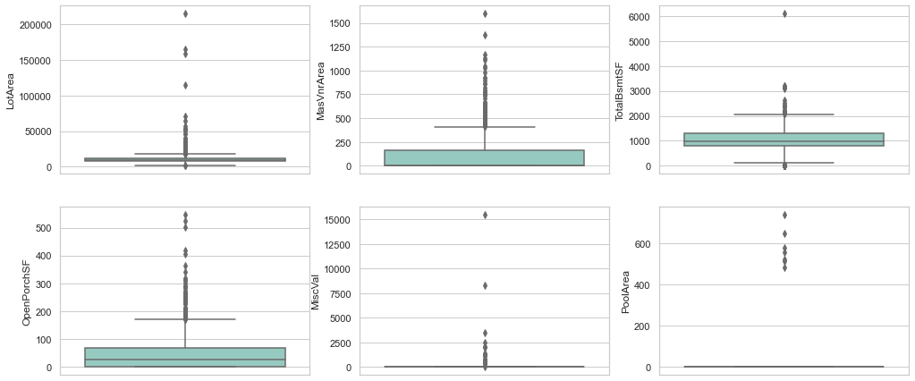

```python
plt.figure(figsize=(17, 20))
plt.subplot(5,3,1)
sns.boxplot(y = 'LotArea', palette='Set3', data = housing_price)
plt.subplot(5,3,2)
sns.boxplot(y = 'MasVnrArea', palette='Set3', data = housing_price)
plt.subplot(5,3,3)
sns.boxplot(y = 'TotalBsmtSF', palette='Set3', data = housing_price)
plt.subplot(5,3,4)
sns.boxplot(y = 'OpenPorchSF', palette='Set3', data = housing_price)
plt.subplot(5,3,5)
sns.boxplot(y = 'MiscVal', palette='Set3', data = housing_price)
plt.subplot(5,3,6)
sns.boxplot(y = 'PoolArea', palette='Set3', data = housing_price)
plt.show()
```

```python
num_col = ['LotArea','MasVnrArea','BsmtFinSF1','BsmtFinSF2','TotalBsmtSF','1stFlrSF','GrLivArea','OpenPorchSF',
           'EnclosedPorch','3SsnPorch',
           'ScreenPorch' ,'PoolArea','MiscVal','SalePrice']
def drop_outliers(x):
    list = []
    for col in num_col:
        Q1 = x[col].quantile(.25)
        Q3 = x[col].quantile(.99)
        IQR = Q3-Q1
        x =  x[(x[col] >= (Q1-(1.5*IQR))) & (x[col] <= (Q3+(1.5*IQR)))]
    return x

housing_price = drop_outliers(housing_price)
```

```python
#percentage of data retained
data_retained = round(100*(len(housing_price)/1460),2)
print(data_retained)
```

```
98.7
```

### Step 3: Data Visualization

- Lets visualise the data for analysis  
  **Lets visualise the SalePrice Target variable after removing outliers**

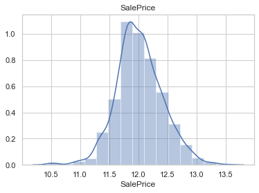

```python
housing_price['SalePrice'] = np.log1p(housing_price['SalePrice'])
sns.distplot(housing_price['SalePrice'], bins=15)
plt.title('SalePrice')
plt.show()
```

Our target variable is following normal distribution with little noise

Lets check the pairplot distribution of numerical values

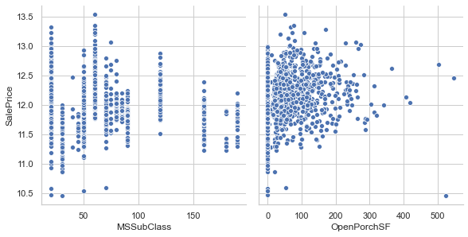

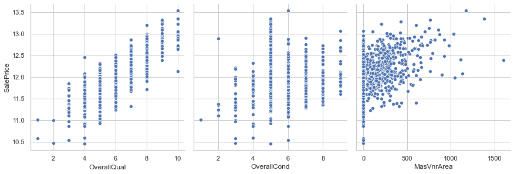

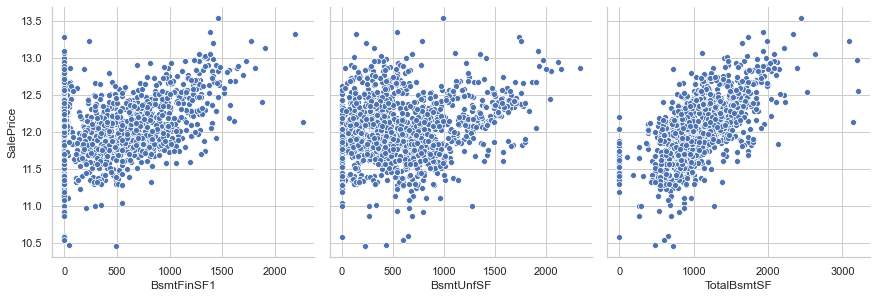

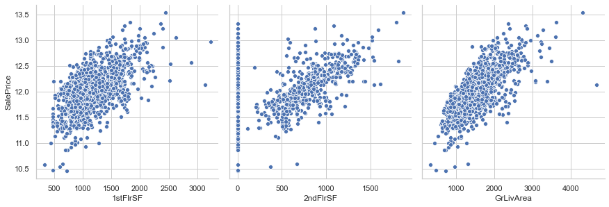

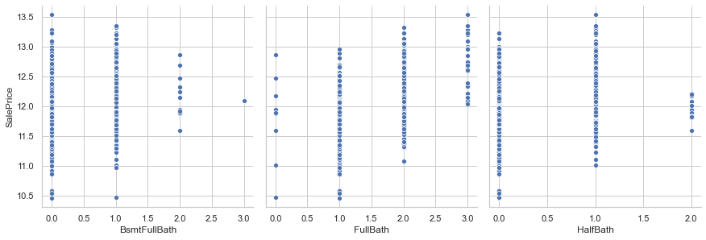

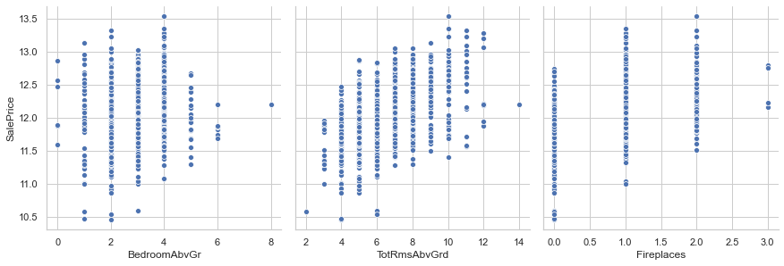

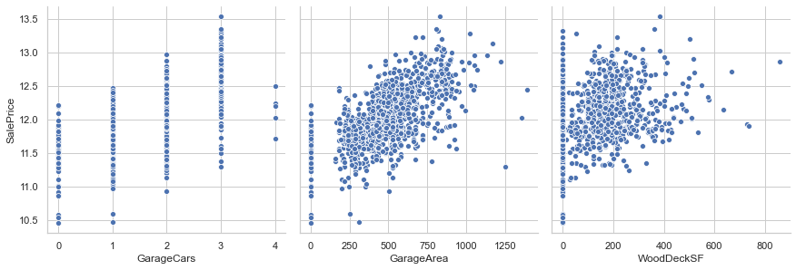

```python
plt.figure(figsize=(10,5))
sns.pairplot(housing_price, x_vars=['MSSubClass','OpenPorchSF'], y_vars='SalePrice',height=4, aspect=1,kind='scatter')
sns.pairplot(housing_price, x_vars=['OverallQual', 'OverallCond','MasVnrArea'], y_vars='SalePrice',height=4, aspect=1,kind='scatter')
sns.pairplot(housing_price, x_vars=['BsmtFinSF1', 'BsmtUnfSF','TotalBsmtSF'], y_vars='SalePrice',height=4, aspect=1,kind='scatter')
sns.pairplot(housing_price, x_vars=['1stFlrSF','2ndFlrSF', 'GrLivArea'], y_vars='SalePrice',height=4, aspect=1,kind='scatter')
sns.pairplot(housing_price, x_vars=['BsmtFullBath','FullBath', 'HalfBath'], y_vars='SalePrice',height=4, aspect=1,kind='scatter')
sns.pairplot(housing_price, x_vars=['BedroomAbvGr','TotRmsAbvGrd', 'Fireplaces'], y_vars='SalePrice',height=4, aspect=1,kind='scatter')
sns.pairplot(housing_price, x_vars=['GarageCars','GarageArea', 'WoodDeckSF'], y_vars='SalePrice',height=4, aspect=1,kind='scatter')
plt.show()
```

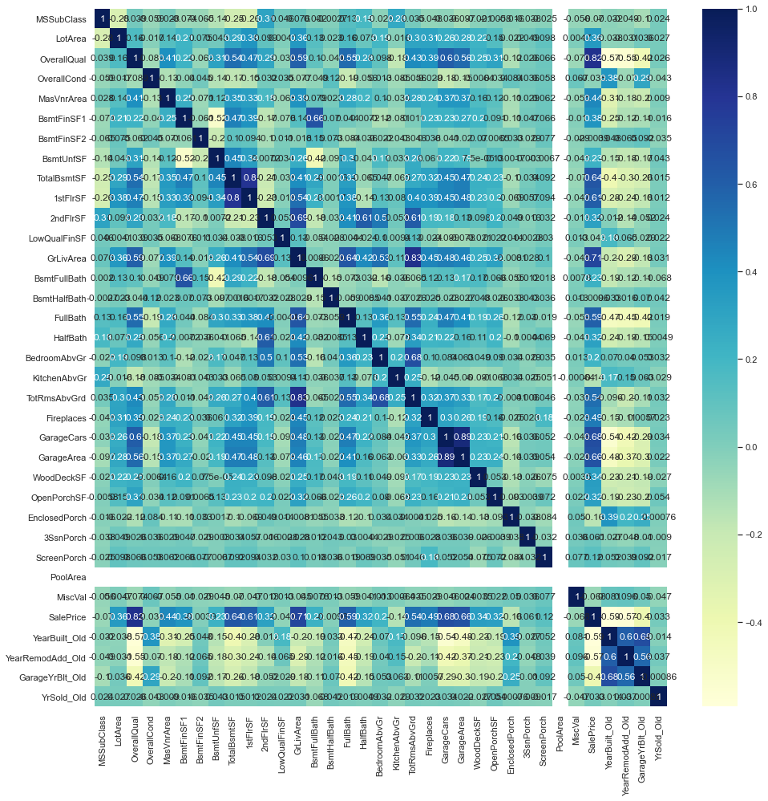

```python
plt.figure(figsize=(16,16))
sns.heatmap(housing_price[list(housing_price.dtypes[housing_price.dtypes!='object'].index)].corr(),annot=True,cmap='YlGnBu')
plt.show()
```

```python
housing_price.shape
```

```
(1441, 55)
```

### Step 4: Data Preparation

- converting categorical data into numerical data
- creating dummies

Before Lets check the categorical data

```python
housing_price[list(housing_price.dtypes[housing_price.dtypes=='object'].index)].head()
```

|  | MSZoning | LotShape | LotConfig | Neighborhood | BldgType | HouseStyle | RoofStyle | Exterior1st | Exterior2nd | MasVnrType | ExterQual | Foundation | BsmtQual | BsmtExposure | BsmtFinType1 | HeatingQC | KitchenQual | GarageType | GarageFinish | SaleCondition |
| --- | --- | --- | --- | --- | --- | --- | --- | --- | --- | --- | --- | --- | --- | --- | --- | --- | --- | --- | --- | --- |
| 0 | RL | Reg | Inside | CollgCr | 1Fam | 2Story | Gable | VinylSd | VinylSd | BrkFace | Gd | PConc | Gd | No | GLQ | Ex | Gd | Attchd | RFn | Normal |
| 1 | RL | Reg | FR2 | Veenker | 1Fam | 1Story | Gable | MetalSd | MetalSd | None | TA | CBlock | Gd | Gd | ALQ | Ex | TA | Attchd | RFn | Normal |
| 2 | RL | IR1 | Inside | CollgCr | 1Fam | 2Story | Gable | VinylSd | VinylSd | BrkFace | Gd | PConc | Gd | Mn | GLQ | Ex | Gd | Attchd | RFn | Normal |
| 3 | RL | IR1 | Corner | Crawfor | 1Fam | 2Story | Gable | Wd Sdng | Wd Shng | None | TA | BrkTil | TA | No | ALQ | Gd | Gd | Detchd | Unf | Abnorml |
| 4 | RL | IR1 | FR2 | NoRidge | 1Fam | 2Story | Gable | VinylSd | VinylSd | BrkFace | Gd | PConc | Gd | Av | GLQ | Ex | Gd | Attchd | RFn | Normal |

Lets check for the below columns,As in Data Dictionary,here we can clearly see that these are having some kind of order and hence we can say these are ordinal in nature

```python
housing_price[['ExterQual','BsmtQual','BsmtExposure','BsmtFinType1','HeatingQC','KitchenQual','GarageFinish','LotShape']].head()
```

|  | ExterQual | BsmtQual | BsmtExposure | BsmtFinType1 | HeatingQC | KitchenQual | GarageFinish | LotShape |
| --- | --- | --- | --- | --- | --- | --- | --- | --- |
| 0 | Gd | Gd | No | GLQ | Ex | Gd | RFn | Reg |
| 1 | TA | Gd | Gd | ALQ | Ex | TA | RFn | Reg |
| 2 | Gd | Gd | Mn | GLQ | Ex | Gd | RFn | IR1 |
| 3 | TA | TA | No | ALQ | Gd | Gd | Unf | IR1 |
| 4 | Gd | Gd | Av | GLQ | Ex | Gd | RFn | IR1 |

converting Categorical columns into numerical ones as they are ordinal in nature

```python
housing_price['ExterQual'] = housing_price.ExterQual.map({'Po':0,'Fa':1,'TA':2,'Gd':3,'Ex':4})
housing_price['BsmtQual'] = housing_price.BsmtQual.map({'NA':0,'Po':1,'Fa':2,'TA':3,'Gd':4,'Ex':5})
housing_price['BsmtExposure'] = housing_price.BsmtExposure.map({'NA':0,'No':1,'Mn':2,'Av':3,'Gd':4})
housing_price['BsmtFinType1'] = housing_price.BsmtFinType1.map({'NA':0,'Unf':1,'LwQ':2,'Rec':3,'BLQ':4,'ALQ':5,'GLQ':6})
housing_price['HeatingQC'] = housing_price.HeatingQC.map({'Po':0,'Fa':1,'TA':2,'Gd':3,'Ex':4})
housing_price['KitchenQual'] = housing_price.KitchenQual.map({'Po':0,'Fa':1,'TA':2,'Gd':3,'Ex':4})
housing_price['GarageFinish'] = housing_price.GarageFinish.map({'NA':0,'Unf':1,'RFn':2,'Fin':3})
housing_price['LotShape'] = housing_price.LotShape.map({'IR1':0,'IR2':1,'IR3':2,'Reg':3})
```

```python
# Lets check the converted columns
housing_price[['ExterQual','BsmtQual','BsmtExposure','BsmtFinType1','HeatingQC',  'KitchenQual','GarageFinish','LotShape']].head()
```

|  | ExterQual | BsmtQual | BsmtExposure | BsmtFinType1 | HeatingQC | KitchenQual | GarageFinish | LotShape |
| --- | --- | --- | --- | --- | --- | --- | --- | --- |
| 0 | 3 | 4 | 1 | 6 | 4 | 3 | 2 | 3 |
| 1 | 2 | 4 | 4 | 5 | 4 | 2 | 2 | 3 |
| 2 | 3 | 4 | 2 | 6 | 4 | 3 | 2 | 0 |
| 3 | 2 | 3 | 1 | 5 | 3 | 3 | 1 | 0 |
| 4 | 3 | 4 | 3 | 6 | 4 | 3 | 2 | 0 |

**Creating Dummy columns**

```python
#Creating and joining dummy column with the actual dataset
dummy_col = pd.get_dummies(housing_price[['MSZoning','LotConfig','Neighborhood','BldgType','HouseStyle','RoofStyle','Exterior1st',  'Exterior2nd','MasVnrType','Foundation','GarageType','SaleCondition']],drop_first=True)

housing_price = pd.concat([housing_price,dummy_col],axis='columns')

housing_price = housing_price.drop(['MSZoning','LotConfig','Neighborhood','BldgType','HouseStyle','RoofStyle','Exterior1st',  'Exterior2nd','MasVnrType','Foundation','GarageType','SaleCondition'],axis='columns')
```

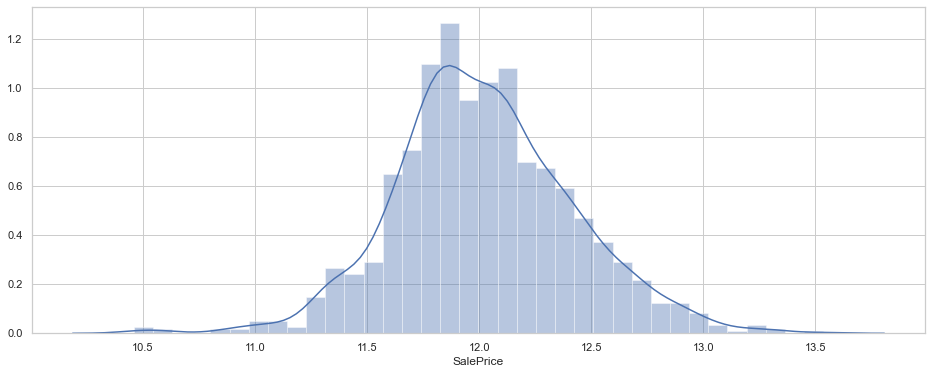

```python
#Let us check the distribution of our target variable before scaling and Splitting
plt.figure(figsize=(16,6))
sns.distplot(housing_price.SalePrice)
plt.show()
```

### Step 5: Train Test Split

```python
#Creating train and test dataset for validation purpose
df_train,df_test = train_test_split(housing_price,train_size=0.7,test_size=0.3,random_state=42)
```

```python
housing_price[['ExterQual','BsmtQual','BsmtExposure','BsmtFinType1', 'HeatingQC','KitchenQual','GarageFinish','LotShape']].head()
```

|  | ExterQual | BsmtQual | BsmtExposure | BsmtFinType1 | HeatingQC | KitchenQual | GarageFinish | LotShape |
| --- | --- | --- | --- | --- | --- | --- | --- | --- |
| 0 | 3 | 4 | 1 | 6 | 4 | 3 | 2 | 3 |
| 1 | 2 | 4 | 4 | 5 | 4 | 2 | 2 | 3 |
| 2 | 3 | 4 | 2 | 6 | 4 | 3 | 2 | 0 |
| 3 | 2 | 3 | 1 | 5 | 3 | 3 | 1 | 0 |
| 4 | 3 | 4 | 3 | 6 | 4 | 3 | 2 | 0 |

**Scaling the train and test dataset and applying standard scaler**

```python
#Scaling the train and test dataset
num_col = ['MSSubClass','LotArea','OverallQual','OverallCond',
           'MasVnrArea','BsmtFinSF1',
           'BsmtFinSF2','BsmtUnfSF','TotalBsmtSF','1stFlrSF','2ndFlrSF',
           'LowQualFinSF','GrLivArea','BsmtFullBath','BsmtHalfBath','FullBath','HalfBath','BedroomAbvGr',
           'KitchenAbvGr','TotRmsAbvGrd','Fireplaces','GarageCars',
           'GarageArea','WoodDeckSF','OpenPorchSF','EnclosedPorch','3SsnPorch',
           'ScreenPorch','PoolArea','MiscVal','SalePrice']

scaler = StandardScaler()
df_train[num_col] = scaler.fit_transform(df_train[num_col])
df_test[num_col] = scaler.transform(df_test[num_col])
```

**Lets check the distribution after splitting and scaling**

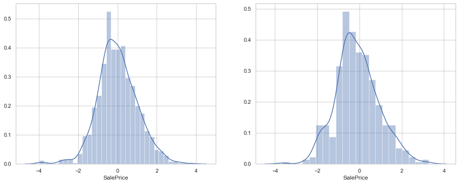

```python
plt.figure(figsize=(16,6))
plt.subplot(121)
sns.distplot(df_train.SalePrice)
plt.subplot(122)
sns.distplot(df_test.SalePrice)
```

Spliting the dependent and independent variable

```python
y_train = df_train.pop('SalePrice')
X_train = df_train
```

```python
y_test = df_test.pop('SalePrice')
X_test = df_test
```

**Now using RFE lets try to to find the optimal number of feature, Note : I cannot use RFE with GridSearchCV as 137 variable with 5 folds will create 685 fit and it will take more then 1 Hour to get the result so i am using RFE directly**

```python
print(len(X_train.columns))
print(X_train.shape)
```

```
137
(1008, 137)
```

**Now using RFE lets try to to find the optimal number of feature , lets get top 70 optimal independant features**

```python
lm  = LinearRegression()
lm.fit(X_train,y_train)
rfe = RFE(lm,70)
rfe.fit(X_train,y_train)
```

```
RFE(estimator=LinearRegression(copy_X=True, fit_intercept=True, n_jobs=None,
                               normalize=False),
    n_features_to_select=70, step=1, verbose=0)
```

```python
rfe_scores = pd.DataFrame(list(zip(X_train.columns,rfe.support_,rfe.ranking_)))
rfe_scores.columns = ['Column_Names','Status','Rank']
```

```python
rfe_sel_columns = list(rfe_scores[rfe_scores.Status==True].Column_Names)
```

**Lets filter the train and test set for the RFE selected columns**

```python
X_train = X_train[rfe_sel_columns]
X_test = X_test[rfe_sel_columns]
X_train.head()
```

|  | MSSubClass | LotArea | OverallQual | OverallCond | BsmtFinSF1 | BsmtFinSF2 | BsmtUnfSF | TotalBsmtSF | HeatingQC | 1stFlrSF | 2ndFlrSF | LowQualFinSF | GrLivArea | KitchenAbvGr | KitchenQual | Fireplaces | GarageFinish | GarageCars | GarageArea | MSZoning_FV | MSZoning_RH | MSZoning_RL | MSZoning_RM | LotConfig_FR2 | LotConfig_FR3 | Neighborhood_Crawfor | Neighborhood_Edwards | Neighborhood_IDOTRR | Neighborhood_NAmes | … |
| --- | --- | --- | --- | --- | --- | --- | --- | --- | --- | --- | --- | --- | --- | --- | --- | --- | --- | --- | --- | --- | --- | --- | --- | --- | --- | --- | --- | --- | --- | --- |
| 1180 | 0.0784 | 0.1799 | 0.6402 | -0.5192 | 1.7825 | -0.3001 | -1.2706 | 0.3851 | 4 | 0.3772 | 1.9351 | -0.1238 | 1.9146 | -0.2169 | 2 | -0.9439 | 3 | 0.2852 | 1.0253 | 0 | 0 | 1 | 0 | 0 | 0 | 0 | 0 | 0 | 0 | … |
| 445 | -0.8842 | -0.0472 | -0.0906 | -0.5192 | -1.0167 | -0.3001 | 1.9820 | 0.9149 | 1 | 1.4422 | -0.8192 | -0.1238 | 0.3135 | -0.2169 | 2 | 0.6419 | 1 | 0.2852 | 0.0201 | 0 | 0 | 1 | 0 | 0 | 0 | 0 | 1 | 0 | 0 | … |
| 986 | -0.1622 | -0.8319 | -0.0906 | 2.1646 | -1.0167 | -0.3001 | -0.1720 | -1.3753 | 3 | -0.4318 | 0.6168 | -0.1238 | 0.2086 | -0.2169 | 3 | -0.9439 | 1 | -1.0582 | -1.0418 | 0 | 0 | 0 | 1 | 0 | 0 | 0 | 0 | 0 | 0 | … |
| 416 | 0.0784 | -0.3944 | -0.0906 | 1.2700 | -0.5356 | -0.3001 | -0.2219 | -0.9250 | 2 | -1.3279 | 0.8297 | -0.1238 | -0.2474 | -0.2169 | 2 | 0.6419 | 3 | 0.2852 | -0.1687 | 0 | 0 | 1 | 0 | 0 | 0 | 0 | 0 | 0 | 0 | … |
| 767 | -0.1622 | 0.4109 | -0.0906 | 1.2700 | 0.5026 | -0.3001 | -0.5390 | -0.1760 | 4 | -0.4808 | 0.9181 | -0.1238 | 0.4318 | -0.2169 | 2 | -0.9439 | 1 | -1.0582 | -0.2489 | 0 | 0 | 1 | 0 | 0 | 0 | 0 | 0 | 0 | 0 | … |

### Lasso regression model

```python
lm = Lasso(alpha=0.001)
lm.fit(X_train,y_train)

y_train_pred = lm.predict(X_train)
print(r2_score(y_true=y_train,y_pred=y_train_pred))

y_test_pred  = lm.predict(X_test)
print(r2_score(y_true=y_test,y_pred=y_test_pred))
```

```
0.9087319749623419
0.8914416699723886
```

```python
model_parameter = list(lm.coef_)
model_parameter.insert(0,lm.intercept_)
model_parameter = [round(x,3) for x in model_parameter]
col = df_train.columns
col.insert(0,'Constant')
list(zip(col,model_parameter))
```

```
[('MSSubClass', -0.925),
 ('LotArea', -0.02),
 ('LotShape', 0.056),
 ('OverallQual', 0.235),
 ('OverallCond', 0.116),
 ('MasVnrArea', 0.108),
 ('ExterQual', 0.03),
 ('BsmtQual', -0.0),
 ('BsmtExposure', 0.105),
 ('BsmtFinType1', 0.041),
 ('BsmtFinSF1', 0.0),
 ('BsmtFinSF2', 0.052),
 ('BsmtUnfSF', -0.001),
 ('TotalBsmtSF', 0.251),
 ('HeatingQC', -0.044),
 ('1stFlrSF', 0.084),
 ('2ndFlrSF', 0.044),
 ('LowQualFinSF', 0.049),
 ('GrLivArea', 0.073),
 ('BsmtFullBath', 0.076),
 ('BsmtHalfBath', 0.293),
 ('FullBath', 0.15),
 ('HalfBath', 0.252),
 ('BedroomAbvGr', 0.076),
 ('KitchenAbvGr', -0.03),
 ('KitchenQual', -0.0),
 ('TotRmsAbvGrd', 0.207),
 ('Fireplaces', -0.224),
 ('GarageFinish', -0.246),
 ('GarageCars', -0.059),
 ('GarageArea', 0.06),
 ('WoodDeckSF', 0.244),
 ('OpenPorchSF', -0.212),
 ('EnclosedPorch', -0.069),
 ('3SsnPorch', 0.096),
 ('ScreenPorch', 0.198),
 ('PoolArea', 0.029),
 ('MiscVal', 0.0),
 ('YearBuilt_Old', 0.134),
 ('YearRemodAdd_Old', -0.08),
```

[output cut: 16 more lines]

```
 ('Neighborhood_Edwards', -0.0),
 ('Neighborhood_Gilbert', 0.0),
 ('Neighborhood_IDOTRR', 0.048),
 ('Neighborhood_MeadowV', 0.18),
 ('Neighborhood_Mitchel', 0.0),
 ('Neighborhood_NAmes', 0.0),
 ('Neighborhood_NPkVill', 0.07),
 ('Neighborhood_NWAmes', -0.0),
 ('Neighborhood_NoRidge', 0.0),
 ('Neighborhood_NridgHt', 0.008),
 ('Neighborhood_OldTown', 0.0),
 ('Neighborhood_SWISU', 0.0),
 ('Neighborhood_Sawyer', 0.0),
 ('Neighborhood_SawyerW', 0.152),
 ('Neighborhood_Somerst', 0.199)]
```

**Now lets try to improve our model with the optimal value of alpha using GridSearchCV**

```python
folds = KFold(n_splits=10,shuffle=True,random_state=42)

hyper_param = {'alpha':[0.001, 0.01, 0.1,1.0, 5.0, 10.0,20.0]}

model = Lasso()

model_cv = GridSearchCV(estimator = model,
                        param_grid=hyper_param,
                        scoring='r2',
                        cv=folds,
                        verbose=1,
                        return_train_score=True
                       )

model_cv.fit(X_train,y_train)
```

```
Fitting 10 folds for each of 7 candidates, totalling 70 fits
```

```
[Parallel(n_jobs=1)]: Using backend SequentialBackend with 1 concurrent workers.
[Parallel(n_jobs=1)]: Done  70 out of  70 | elapsed:    0.8s finished
```

```
GridSearchCV(cv=KFold(n_splits=10, random_state=42, shuffle=True),
             error_score=nan,
             estimator=Lasso(alpha=1.0, copy_X=True, fit_intercept=True,
                             max_iter=1000, normalize=False, positive=False,
                             precompute=False, random_state=None,
                             selection='cyclic', tol=0.0001, warm_start=False),
             iid='deprecated', n_jobs=None,
             param_grid={'alpha': [0.001, 0.01, 0.1, 1.0, 5.0, 10.0, 20.0]},
             pre_dispatch='2*n_jobs', refit=True, return_train_score=True,
             scoring='r2', verbose=1)
```

```python
cv_result_l = pd.DataFrame(model_cv.cv_results_)
cv_result_l['param_alpha'] = cv_result_l['param_alpha'].astype('float32')
cv_result_l.head()
```

|  | mean_fit_time | std_fit_time | mean_score_time | std_score_time | param_alpha | params | split0_test_score | split1_test_score | split2_test_score | split3_test_score | split4_test_score | split5_test_score | split6_test_score | split7_test_score | split8_test_score | split9_test_score | mean_test_score | std_test_score | rank_test_score | split0_train_score | split1_train_score | split2_train_score | split3_train_score | split4_train_score | split5_train_score | split6_train_score | split7_train_score | split8_train_score | split9_train_score | … |
| --- | --- | --- | --- | --- | --- | --- | --- | --- | --- | --- | --- | --- | --- | --- | --- | --- | --- | --- | --- | --- | --- | --- | --- | --- | --- | --- | --- | --- | --- | --- |
| 0 | 0.0300 | 0.0092 | 0.0020 | 0.0024 | 0.0010 | {'alpha': 0.001} | 0.8730 | 0.9156 | 0.9250 | 0.8956 | 0.9257 | 0.9164 | 0.9244 | 0.6884 | 0.8923 | 0.9102 | 0.8867 | 0.0681 | 1 | 0.9114 | 0.9083 | 0.9067 | 0.9101 | 0.9085 | 0.9071 | 0.9072 | 0.9241 | 0.9097 | 0.9089 | … |
| 1 | 0.0095 | 0.0027 | 0.0010 | 0.0020 | 0.0100 | {'alpha': 0.01} | 0.8579 | 0.9011 | 0.9204 | 0.8793 | 0.9194 | 0.8767 | 0.9200 | 0.6508 | 0.8697 | 0.9069 | 0.8702 | 0.0763 | 2 | 0.8891 | 0.8839 | 0.8827 | 0.8876 | 0.8834 | 0.8870 | 0.8810 | 0.9061 | 0.8884 | 0.8839 | … |
| 2 | 0.0062 | 0.0076 | 0.0000 | 0.0000 | 0.1000 | {'alpha': 0.1} | 0.8055 | 0.8228 | 0.8696 | 0.8120 | 0.8436 | 0.8132 | 0.8511 | 0.6548 | 0.8007 | 0.8414 | 0.8115 | 0.0563 | 3 | 0.8244 | 0.8223 | 0.8163 | 0.8243 | 0.8188 | 0.8244 | 0.8149 | 0.8451 | 0.8228 | 0.8200 | … |
| 3 | 0.0031 | 0.0062 | 0.0016 | 0.0047 | 1.0000 | {'alpha': 1.0} | -0.0013 | -0.0284 | -0.0208 | -0.0013 | -0.0006 | -0.0068 | -0.0011 | -0.0233 | -0.0050 | -0.0149 | -0.0103 | 0.0100 | 4 | 0.0000 | 0.0000 | 0.0000 | 0.0000 | 0.0000 | 0.0000 | 0.0000 | 0.0000 | 0.0000 | 0.0000 | … |
| 4 | 0.0031 | 0.0062 | 0.0016 | 0.0047 | 5.0000 | {'alpha': 5.0} | -0.0013 | -0.0284 | -0.0208 | -0.0013 | -0.0006 | -0.0068 | -0.0011 | -0.0233 | -0.0050 | -0.0149 | -0.0103 | 0.0100 | 4 | 0.0000 | 0.0000 | 0.0000 | 0.0000 | 0.0000 | 0.0000 | 0.0000 | 0.0000 | 0.0000 | 0.0000 | … |

**Lets visualise alpha with mean test and train score of all the resulted models**

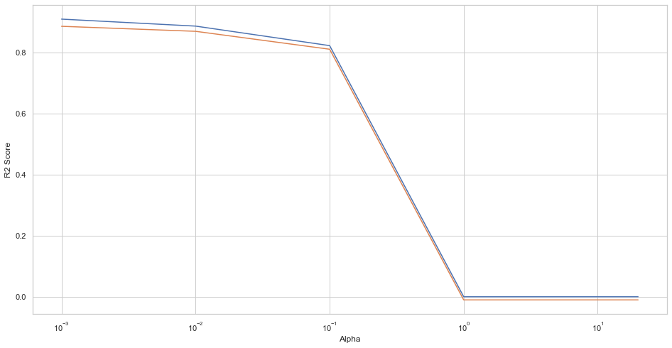

```python
plt.figure(figsize=(16,8))
plt.plot(cv_result_l['param_alpha'],cv_result_l['mean_train_score'])
plt.plot(cv_result_l['param_alpha'],cv_result_l['mean_test_score'])
plt.xscale('log')
plt.ylabel('R2 Score')
plt.xlabel('Alpha')
plt.show()
```

```python
# Checking the best parameter(Alpha value)
model_cv.best_params_
```

```
{'alpha': 0.001}
```

```python
lasso = Lasso(alpha=0.001)
lasso.fit(X_train,y_train)

y_train_pred = lasso.predict(X_train)
y_test_pred = lasso.predict(X_test)

print(r2_score(y_true=y_train,y_pred=y_train_pred))
print(r2_score(y_true=y_test,y_pred=y_test_pred))
```

```
0.9087319749623419
0.8914416699723886
```

```python
model_param = list(lasso.coef_)
model_param.insert(0,lasso.intercept_)
cols = df_train.columns
cols.insert(0,'const')
lasso_coef = pd.DataFrame(list(zip(cols,model_param)))
lasso_coef.columns = ['Feature','Coef']
```

```python
l_top10=lasso_coef.sort_values(by='Coef',ascending=False).head(10)
```

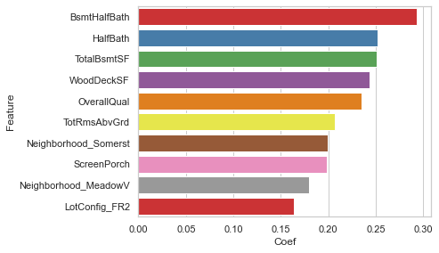

```python
#top10 predictors for house price are
l_top10=lasso_coef.sort_values(by='Coef',ascending=False).head(10)
plt.figure(figsize=(20,20))
plt.subplot(4,3,1)
sns.barplot(y = 'Feature', x='Coef', palette='Set1', data = l_top10)
plt.show()
```

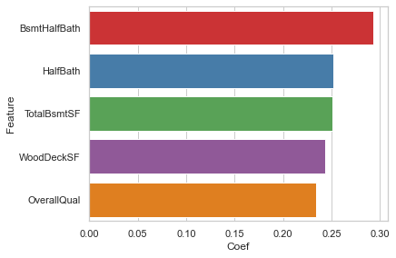

```python
#top5 predictors are
l_top5=lasso_coef.sort_values(by='Coef',ascending=False).head(5)
plt.figure(figsize=(20,20))
plt.subplot(4,3,1)
sns.barplot(y = 'Feature', x='Coef', palette='Set1', data = l_top5)
plt.show()
```

### Ridge Regression

```python
ridge = Ridge(alpha=0.001)
ridge.fit(X_train,y_train)

y_train_pred = ridge.predict(X_train)
print(r2_score(y_train,y_train_pred))
y_test_pred = ridge.predict(X_test)
print(r2_score(y_test,y_test_pred))
```

```
0.9158623345152271
0.8891574779075181
```

**Now lets try to improve our model with the optimal value of alpha using GridSearchCV**

```python
folds  = KFold(n_splits=10,shuffle=True,random_state=42)

hyper_param = {'alpha':[0.001,0.01,0.1,0.2,0.5,0.9,1.0, 5.0, 10.0,20.0]}

model = Ridge()

model_cv = GridSearchCV(estimator=model,
                        param_grid=hyper_param,
                        scoring='r2',
                        cv=folds,
                        verbose=1,
                        return_train_score=True)

model_cv.fit(X_train,y_train)
```

```
Fitting 10 folds for each of 10 candidates, totalling 100 fits
```

```
[Parallel(n_jobs=1)]: Using backend SequentialBackend with 1 concurrent workers.
[Parallel(n_jobs=1)]: Done 100 out of 100 | elapsed:    0.7s finished
```

```
GridSearchCV(cv=KFold(n_splits=10, random_state=42, shuffle=True),
             error_score=nan,
             estimator=Ridge(alpha=1.0, copy_X=True, fit_intercept=True,
                             max_iter=None, normalize=False, random_state=None,
                             solver='auto', tol=0.001),
             iid='deprecated', n_jobs=None,
             param_grid={'alpha': [0.001, 0.01, 0.1, 0.2, 0.5, 0.9, 1.0, 5.0,
                                   10.0, 20.0]},
             pre_dispatch='2*n_jobs', refit=True, return_train_score=True,
             scoring='r2', verbose=1)
```

```python
cv_result_r = pd.DataFrame(model_cv.cv_results_)
cv_result_r['param_alpha'] = cv_result_r['param_alpha'].astype('float32')
cv_result_r.head()
```

|  | mean_fit_time | std_fit_time | mean_score_time | std_score_time | param_alpha | params | split0_test_score | split1_test_score | split2_test_score | split3_test_score | split4_test_score | split5_test_score | split6_test_score | split7_test_score | split8_test_score | split9_test_score | mean_test_score | std_test_score | rank_test_score | split0_train_score | split1_train_score | split2_train_score | split3_train_score | split4_train_score | split5_train_score | split6_train_score | split7_train_score | split8_train_score | split9_train_score | … |
| --- | --- | --- | --- | --- | --- | --- | --- | --- | --- | --- | --- | --- | --- | --- | --- | --- | --- | --- | --- | --- | --- | --- | --- | --- | --- | --- | --- | --- | --- | --- |
| 0 | 0.0035 | 0.0023 | 0.0015 | 0.0023 | 0.0010 | {'alpha': 0.001} | 0.8783 | 0.9044 | 0.9256 | 0.8990 | 0.8767 | 0.9392 | 0.8902 | 0.7169 | 0.9051 | 0.9046 | 0.8840 | 0.0586 | 10 | 0.9179 | 0.9150 | 0.9134 | 0.9170 | 0.9167 | 0.9130 | 0.9155 | 0.9305 | 0.9156 | 0.9162 | … |
| 1 | 0.0036 | 0.0047 | 0.0021 | 0.0048 | 0.0100 | {'alpha': 0.01} | 0.8782 | 0.9045 | 0.9257 | 0.8989 | 0.8780 | 0.9391 | 0.8909 | 0.7168 | 0.9049 | 0.9046 | 0.8842 | 0.0586 | 9 | 0.9179 | 0.9150 | 0.9134 | 0.9170 | 0.9167 | 0.9130 | 0.9155 | 0.9305 | 0.9156 | 0.9162 | … |
| 2 | 0.0062 | 0.0076 | 0.0000 | 0.0000 | 0.1000 | {'alpha': 0.1} | 0.8778 | 0.9050 | 0.9258 | 0.8988 | 0.8885 | 0.9385 | 0.8967 | 0.7160 | 0.9039 | 0.9049 | 0.8856 | 0.0588 | 8 | 0.9178 | 0.9149 | 0.9134 | 0.9169 | 0.9166 | 0.9129 | 0.9154 | 0.9305 | 0.9155 | 0.9162 | … |
| 3 | 0.0051 | 0.0040 | 0.0036 | 0.0047 | 0.2000 | {'alpha': 0.2} | 0.8774 | 0.9056 | 0.9260 | 0.8987 | 0.8964 | 0.9374 | 0.9015 | 0.7151 | 0.9029 | 0.9051 | 0.8866 | 0.0592 | 7 | 0.9177 | 0.9148 | 0.9133 | 0.9168 | 0.9163 | 0.9128 | 0.9152 | 0.9303 | 0.9154 | 0.9160 | … |
| 4 | 0.0060 | 0.0020 | 0.0015 | 0.0023 | 0.5000 | {'alpha': 0.5} | 0.8765 | 0.9070 | 0.9263 | 0.8983 | 0.9093 | 0.9338 | 0.9107 | 0.7125 | 0.9005 | 0.9056 | 0.8881 | 0.0603 | 5 | 0.9173 | 0.9143 | 0.9127 | 0.9163 | 0.9153 | 0.9122 | 0.9143 | 0.9299 | 0.9151 | 0.9155 | … |

**Lets visualise alpha with R2 Score**

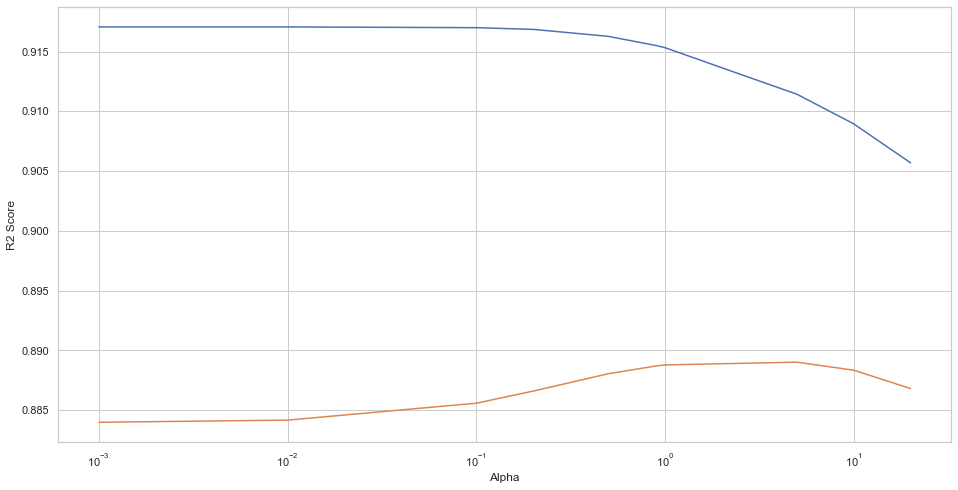

```python
plt.figure(figsize=(16,8))
plt.plot(cv_result_r['param_alpha'],cv_result_r['mean_train_score'])
plt.plot(cv_result_r['param_alpha'],cv_result_r['mean_test_score'])
plt.xlabel('Alpha')
plt.xscale('log')
plt.ylabel('R2 Score')
plt.show()
```

- From 0.9 the model is showing good improvement and R2 score is similar from 0.9 to 5 which is best so we will take alpha to be 5 from the below best params

```python
# Checking the best parameter(Alpha value)
model_cv.best_params_
```

```
{'alpha': 5.0}
```

```python
ridge = Ridge(alpha = 5)
ridge.fit(X_train,y_train)

y_pred_train = ridge.predict(X_train)
print(r2_score(y_train,y_pred_train))

y_pred_test = ridge.predict(X_test)
print(r2_score(y_test,y_pred_test))
```

```
0.9108392207417129
0.889635842400985
```

```python
model_parameter = list(ridge.coef_)
model_parameter.insert(0,ridge.intercept_)
cols = df_train.columns
cols.insert(0,'constant')
ridge_coef = pd.DataFrame(list(zip(cols,model_parameter)))
ridge_coef.columns = ['Feature','Coef']
```

```python
ridge_coef.sort_values(by='Coef',ascending=False).head(10)
```

|  | Feature | Coef |
| --- | --- | --- |
| 20 | BsmtHalfBath | 0.2595 |
| 22 | HalfBath | 0.2561 |
| 31 | WoodDeckSF | 0.2511 |
| 3 | OverallQual | 0.2293 |
| 35 | ScreenPorch | 0.2131 |
| 70 | Neighborhood_Somerst | 0.2126 |
| 26 | TotRmsAbvGrd | 0.2123 |
| 21 | FullBath | 0.1811 |
| 59 | Neighborhood_MeadowV | 0.1794 |
| 69 | Neighborhood_SawyerW | 0.1708 |

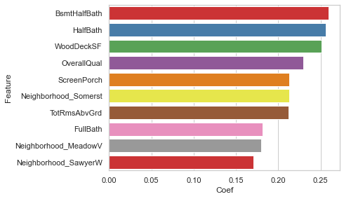

```python
r_top10=ridge_coef.sort_values(by='Coef',ascending=False).head(10)
plt.figure(figsize=(20,20))
plt.subplot(4,3,1)
sns.barplot(y = 'Feature', x='Coef', palette='Set1', data = r_top10)
plt.show()
```

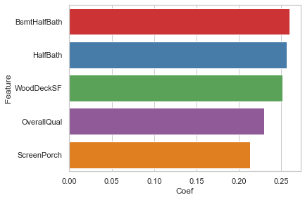

```python
r_top5=ridge_coef.sort_values(by='Coef',ascending=False).head(5)
plt.figure(figsize=(20,20))
plt.subplot(4,3,1)
sns.barplot(y = 'Feature', x='Coef', palette='Set1', data = r_top5)
plt.show()
```

### The best Model : Lasso Regression with alpha 0.001

- Hence Lasso made some coefficients to zero , and performing better on test data we will choose Lasso

```python
lasso = Lasso(alpha=0.001)
lasso.fit(X_train,y_train)

y_train_pred = lasso.predict(X_train)
y_test_pred = lasso.predict(X_test)

print(r2_score(y_true=y_train,y_pred=y_train_pred))
print(r2_score(y_true=y_test,y_pred=y_test_pred))
```

```
0.9087319749623419
0.8914416699723886
```

```python
#top 5 important predictor variables are
lasso_coef.sort_values(by='Coef',ascending=False).head(5)
```

|  | Feature | Coef |
| --- | --- | --- |
| 20 | BsmtHalfBath | 0.2932 |
| 22 | HalfBath | 0.2516 |
| 13 | TotalBsmtSF | 0.2512 |
| 31 | WoodDeckSF | 0.2438 |
| 3 | OverallQual | 0.2346 |

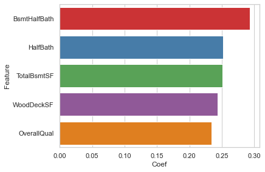

```python
plt.figure(figsize=(20,20))
plt.subplot(4,3,1)
sns.barplot(y = 'Feature', x='Coef', palette='Set1', data = l_top5)
plt.show()
```

### Part2 of Assignment

- if alpha value is doubled what are the changes observed

```python
lasso = Lasso(alpha=0.002)
lasso.fit(X_train,y_train)

y_train_pred = lasso.predict(X_train)
y_test_pred = lasso.predict(X_test)

print(r2_score(y_true=y_train,y_pred=y_train_pred))
print(r2_score(y_true=y_test,y_pred=y_test_pred))
```

```
0.9050762421803374
0.8905998099253559
```

```python
model_param = list(lasso.coef_)
model_param.insert(0,lasso.intercept_)
cols = df_train.columns
cols.insert(0,'const')
lasso_coef = pd.DataFrame(list(zip(cols,model_param)))
lasso_coef.columns = ['Feature','Coef']
```

```python
lasso_coef.sort_values(by='Coef',ascending=False).head(10)
```

|  | Feature | Coef |
| --- | --- | --- |
| 13 | TotalBsmtSF | 0.2538 |
| 3 | OverallQual | 0.2483 |
| 20 | BsmtHalfBath | 0.2079 |
| 31 | WoodDeckSF | 0.1858 |
| 22 | HalfBath | 0.1821 |
| 26 | TotRmsAbvGrd | 0.1790 |
| 59 | Neighborhood_MeadowV | 0.1750 |
| 70 | Neighborhood_Somerst | 0.1659 |
| 47 | LotConfig_FR2 | 0.1369 |
| 69 | Neighborhood_SawyerW | 0.1275 |

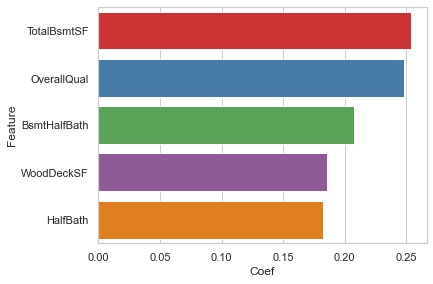

```python
dl_top5=lasso_coef.sort_values(by='Coef',ascending=False).head(5)
plt.figure(figsize=(20,20))
plt.subplot(4,3,1)
sns.barplot(y = 'Feature', x='Coef', palette='Set1', data = dl_top5)
plt.show()
```

**From the Above top five features of Lasso are almost same with their positions changed, i.e; the Model is stable for double the alpha value**

```python
#For Ridge if we double the alpha
ridge = Ridge(alpha = 10)
ridge.fit(X_train,y_train)

y_pred_train = ridge.predict(X_train)
print(r2_score(y_train,y_pred_train))

y_pred_test = ridge.predict(X_test)
print(r2_score(y_test,y_pred_test))
```

```
0.9085494858684259
0.8896035789841154
```

```python
model_parameter = list(ridge.coef_)
model_parameter.insert(0,ridge.intercept_)
cols = df_train.columns
cols.insert(0,'constant')
ridge_coef = pd.DataFrame(list(zip(cols,model_parameter)))
ridge_coef.columns = ['Feature','Coef']
```

```python
ridge_coef.sort_values(by='Coef',ascending=False).head(10)
```

|  | Feature | Coef |
| --- | --- | --- |
| 3 | OverallQual | 0.2361 |
| 31 | WoodDeckSF | 0.2124 |
| 26 | TotRmsAbvGrd | 0.1881 |
| 70 | Neighborhood_Somerst | 0.1853 |
| 22 | HalfBath | 0.1842 |
| 20 | BsmtHalfBath | 0.1799 |
| 59 | Neighborhood_MeadowV | 0.1732 |
| 13 | TotalBsmtSF | 0.1571 |
| 35 | ScreenPorch | 0.1552 |
| 69 | Neighborhood_SawyerW | 0.1497 |

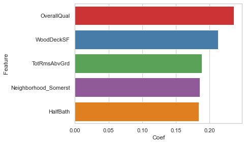

```python
dr_top5=ridge_coef.sort_values(by='Coef',ascending=False).head(5)
plt.figure(figsize=(20,20))
plt.subplot(4,3,1)
sns.barplot(y = 'Feature', x='Coef', palette='Set1', data = dr_top5)
plt.show()
```

**Top Five features of Ridge Model as above for double alpha, and When compared with Lasso, Lasso is more stable and generalisable than Ridge as it has the same features in top five**

**Question3:Dropping top five features of our best Model(Lasso) from the incoming data set and predicting the new top five features from the new model**

```python
#dropping top 5 features from df_train and as y_train remains same so there is no need to change the y_train
df_train=df_train.drop(['BsmtHalfBath','HalfBath','TotalBsmtSF','WoodDeckSF','OverallQual'],axis=1)
X_train = df_train
```

```python
#dropping top 5 features from test data
df_test=df_test.drop(['BsmtHalfBath','HalfBath','TotalBsmtSF','WoodDeckSF','OverallQual'],axis=1)
X_test = df_test
```

```python
print(len(X_train.columns))
print(X_train.shape)
```

```
132
(1008, 132)
```

**Selecting top 70 features from RFE**

```python
lm  = LinearRegression()
lm.fit(X_train,y_train)
rfe = RFE(lm,70)
rfe.fit(X_train,y_train)
```

```
RFE(estimator=LinearRegression(copy_X=True, fit_intercept=True, n_jobs=None,
                               normalize=False),
    n_features_to_select=70, step=1, verbose=0)
```

```python
rfe_scores = pd.DataFrame(list(zip(X_train.columns,rfe.support_,rfe.ranking_)))
rfe_scores.columns = ['Column_Names','Status','Rank']
```

```python
rfe_sel_columns = list(rfe_scores[rfe_scores.Status==True].Column_Names)
```

```python
X_train = X_train[rfe_sel_columns]
X_test = X_test[rfe_sel_columns]
X_train.head()
```

|  | OverallCond | BsmtQual | BsmtFinSF1 | BsmtFinSF2 | BsmtUnfSF | 1stFlrSF | 2ndFlrSF | LowQualFinSF | GrLivArea | KitchenAbvGr | KitchenQual | Fireplaces | GarageFinish | GarageCars | GarageArea | MSZoning_FV | MSZoning_RH | MSZoning_RL | MSZoning_RM | Neighborhood_Blueste | Neighborhood_BrkSide | Neighborhood_Crawfor | Neighborhood_IDOTRR | Neighborhood_MeadowV | Neighborhood_Mitchel | Neighborhood_NAmes | Neighborhood_NWAmes | Neighborhood_NoRidge | Neighborhood_NridgHt | … |
| --- | --- | --- | --- | --- | --- | --- | --- | --- | --- | --- | --- | --- | --- | --- | --- | --- | --- | --- | --- | --- | --- | --- | --- | --- | --- | --- | --- | --- | --- | --- |
| 1180 | -0.5192 | 4 | 1.7825 | -0.3001 | -1.2706 | 0.3772 | 1.9351 | -0.1238 | 1.9146 | -0.2169 | 2 | -0.9439 | 3 | 0.2852 | 1.0253 | 0 | 0 | 1 | 0 | 0 | 0 | 0 | 0 | 0 | 0 | 0 | 0 | 0 | 0 | … |
| 445 | -0.5192 | 3 | -1.0167 | -0.3001 | 1.9820 | 1.4422 | -0.8192 | -0.1238 | 0.3135 | -0.2169 | 2 | 0.6419 | 1 | 0.2852 | 0.0201 | 0 | 0 | 1 | 0 | 0 | 0 | 0 | 0 | 0 | 0 | 0 | 0 | 0 | 0 | … |
| 986 | 2.1646 | 3 | -1.0167 | -0.3001 | -0.1720 | -0.4318 | 0.6168 | -0.1238 | 0.2086 | -0.2169 | 3 | -0.9439 | 1 | -1.0582 | -1.0418 | 0 | 0 | 0 | 1 | 0 | 0 | 0 | 0 | 0 | 0 | 0 | 0 | 0 | 0 | … |
| 416 | 1.2700 | 3 | -0.5356 | -0.3001 | -0.2219 | -1.3279 | 0.8297 | -0.1238 | -0.2474 | -0.2169 | 2 | 0.6419 | 3 | 0.2852 | -0.1687 | 0 | 0 | 1 | 0 | 0 | 0 | 0 | 0 | 0 | 0 | 0 | 0 | 0 | 0 | … |
| 767 | 1.2700 | 4 | 0.5026 | -0.3001 | -0.5390 | -0.4808 | 0.9181 | -0.1238 | 0.4318 | -0.2169 | 2 | -0.9439 | 1 | -1.0582 | -0.2489 | 0 | 0 | 1 | 0 | 0 | 0 | 0 | 0 | 0 | 1 | 0 | 0 | 0 | 0 | … |

Building Lasso Model with alpha value of 0.001

```python
lm = Lasso(alpha=0.001)
lm.fit(X_train,y_train)

y_train_pred = lm.predict(X_train)
print(r2_score(y_true=y_train,y_pred=y_train_pred))

y_test_pred  = lm.predict(X_test)
print(r2_score(y_true=y_test,y_pred=y_test_pred))
```

```
0.8906561432180724
0.8864368475375998
```

```python
model_parameter = list(lm.coef_)
model_parameter.insert(0,lm.intercept_)
model_parameter = [round(x,3) for x in model_parameter]
col = df_train.columns
col.insert(0,'Constant')
list(zip(col,model_parameter))
```

```
[('MSSubClass', -1.65),
 ('LotArea', 0.142),
 ('LotShape', 0.123),
 ('OverallCond', 0.242),
 ('MasVnrArea', 0.093),
 ('ExterQual', 0.159),
 ('BsmtQual', 0.0),
 ('BsmtExposure', 0.062),
 ('BsmtFinType1', -0.002),
 ('BsmtFinSF1', 0.299),
 ('BsmtFinSF2', -0.063),
 ('BsmtUnfSF', 0.157),
 ('HeatingQC', 0.084),
 ('1stFlrSF', 0.061),
 ('2ndFlrSF', 0.107),
 ('LowQualFinSF', 0.089),
 ('GrLivArea', 0.387),
 ('BsmtFullBath', 0.23),
 ('FullBath', 0.377),
 ('BedroomAbvGr', 0.196),
 ('KitchenAbvGr', -0.0),
 ('KitchenQual', 0.0),
 ('TotRmsAbvGrd', 0.28),
 ('Fireplaces', -0.206),
 ('GarageFinish', -0.243),
 ('GarageCars', -0.0),
 ('GarageArea', -0.017),
 ('OpenPorchSF', -0.0),
 ('EnclosedPorch', 0.117),
 ('3SsnPorch', 0.305),
 ('ScreenPorch', -0.149),
 ('PoolArea', -0.029),
 ('MiscVal', -0.0),
 ('YearBuilt_Old', 0.0),
 ('YearRemodAdd_Old', 0.207),
 ('GarageYrBlt_Old', 0.302),
 ('YrSold_Old', 0.107),
 ('MSZoning_FV', 0.0),
 ('MSZoning_RH', 0.128),
 ('MSZoning_RL', -0.097),
```

[output cut: 16 more lines]

```
 ('Neighborhood_NAmes', 0.0),
 ('Neighborhood_NPkVill', 0.0),
 ('Neighborhood_NWAmes', -0.017),
 ('Neighborhood_NoRidge', 0.189),
 ('Neighborhood_NridgHt', 0.0),
 ('Neighborhood_OldTown', -0.0),
 ('Neighborhood_SWISU', 0.107),
 ('Neighborhood_Sawyer', -0.007),
 ('Neighborhood_SawyerW', 0.0),
 ('Neighborhood_Somerst', 0.0),
 ('Neighborhood_StoneBr', 0.0),
 ('Neighborhood_Timber', 0.036),
 ('Neighborhood_Veenker', 0.0),
 ('BldgType_2fmCon', 0.159),
 ('BldgType_Duplex', 0.177)]
```

**Improving the model by using GridSearchCV**

```python
folds = KFold(n_splits=10,shuffle=True,random_state=42)

hyper_param = {'alpha':[0.001, 0.01, 0.1,1.0, 5.0, 10.0,20.0]}

model = Lasso()

model_cv = GridSearchCV(estimator = model,
                        param_grid=hyper_param,
                        scoring='r2',
                        cv=folds,
                        verbose=1,
                        return_train_score=True
                       )

model_cv.fit(X_train,y_train)
```

```
Fitting 10 folds for each of 7 candidates, totalling 70 fits
```

```
[Parallel(n_jobs=1)]: Using backend SequentialBackend with 1 concurrent workers.
[Parallel(n_jobs=1)]: Done  70 out of  70 | elapsed:    0.7s finished
```

```
GridSearchCV(cv=KFold(n_splits=10, random_state=42, shuffle=True),
             error_score=nan,
             estimator=Lasso(alpha=1.0, copy_X=True, fit_intercept=True,
                             max_iter=1000, normalize=False, positive=False,
                             precompute=False, random_state=None,
                             selection='cyclic', tol=0.0001, warm_start=False),
             iid='deprecated', n_jobs=None,
             param_grid={'alpha': [0.001, 0.01, 0.1, 1.0, 5.0, 10.0, 20.0]},
             pre_dispatch='2*n_jobs', refit=True, return_train_score=True,
             scoring='r2', verbose=1)
```

```python
cv_result_l = pd.DataFrame(model_cv.cv_results_)
cv_result_l['param_alpha'] = cv_result_l['param_alpha'].astype('float32')
cv_result_l.head()
```

|  | mean_fit_time | std_fit_time | mean_score_time | std_score_time | param_alpha | params | split0_test_score | split1_test_score | split2_test_score | split3_test_score | split4_test_score | split5_test_score | split6_test_score | split7_test_score | split8_test_score | split9_test_score | mean_test_score | std_test_score | rank_test_score | split0_train_score | split1_train_score | split2_train_score | split3_train_score | split4_train_score | split5_train_score | split6_train_score | split7_train_score | split8_train_score | split9_train_score | … |
| --- | --- | --- | --- | --- | --- | --- | --- | --- | --- | --- | --- | --- | --- | --- | --- | --- | --- | --- | --- | --- | --- | --- | --- | --- | --- | --- | --- | --- | --- | --- |
| 0 | 0.0310 | 0.0078 | 0.0005 | 0.0015 | 0.0010 | {'alpha': 0.001} | 0.8415 | 0.8973 | 0.9048 | 0.8896 | 0.9147 | 0.9068 | 0.9016 | 0.6621 | 0.8566 | 0.8836 | 0.8659 | 0.0714 | 1 | 0.8944 | 0.8895 | 0.8889 | 0.8902 | 0.8895 | 0.8870 | 0.8900 | 0.9065 | 0.8924 | 0.8915 | … |
| 1 | 0.0060 | 0.0020 | 0.0030 | 0.0024 | 0.0100 | {'alpha': 0.01} | 0.8405 | 0.8883 | 0.8912 | 0.8635 | 0.9081 | 0.8728 | 0.8977 | 0.6198 | 0.8325 | 0.8833 | 0.8498 | 0.0800 | 2 | 0.8700 | 0.8631 | 0.8637 | 0.8660 | 0.8614 | 0.8649 | 0.8601 | 0.8865 | 0.8701 | 0.8640 | … |
| 2 | 0.0050 | 0.0000 | 0.0015 | 0.0023 | 0.1000 | {'alpha': 0.1} | 0.8081 | 0.7920 | 0.8096 | 0.7871 | 0.8290 | 0.7856 | 0.8008 | 0.5958 | 0.7411 | 0.8081 | 0.7757 | 0.0639 | 3 | 0.7890 | 0.7834 | 0.7817 | 0.7857 | 0.7818 | 0.7854 | 0.7788 | 0.8147 | 0.7914 | 0.7852 | … |
| 3 | 0.0035 | 0.0023 | 0.0010 | 0.0020 | 1.0000 | {'alpha': 1.0} | -0.0013 | -0.0284 | -0.0208 | -0.0013 | -0.0006 | -0.0068 | -0.0011 | -0.0233 | -0.0050 | -0.0149 | -0.0103 | 0.0100 | 4 | 0.0000 | 0.0000 | 0.0000 | 0.0000 | 0.0000 | 0.0000 | 0.0000 | 0.0000 | 0.0000 | 0.0000 | … |
| 4 | 0.0040 | 0.0020 | 0.0005 | 0.0015 | 5.0000 | {'alpha': 5.0} | -0.0013 | -0.0284 | -0.0208 | -0.0013 | -0.0006 | -0.0068 | -0.0011 | -0.0233 | -0.0050 | -0.0149 | -0.0103 | 0.0100 | 4 | 0.0000 | 0.0000 | 0.0000 | 0.0000 | 0.0000 | 0.0000 | 0.0000 | 0.0000 | 0.0000 | 0.0000 | … |

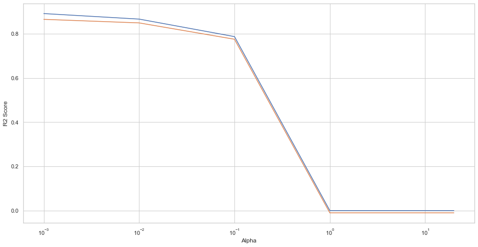

```python
#visualising the alpha value with respect to R2 score
plt.figure(figsize=(16,8))
plt.plot(cv_result_l['param_alpha'],cv_result_l['mean_train_score'])
plt.plot(cv_result_l['param_alpha'],cv_result_l['mean_test_score'])
plt.xscale('log')
plt.ylabel('R2 Score')
plt.xlabel('Alpha')
plt.show()
```

```python
# Checking the best parameter(Alpha value)
model_cv.best_params_
```

```
{'alpha': 0.001}
```

**Building the alpha value with best obtained alpha value**

```python
lasso = Lasso(alpha=0.001)
lasso.fit(X_train,y_train)

y_train_pred = lasso.predict(X_train)
y_test_pred = lasso.predict(X_test)

print(r2_score(y_true=y_train,y_pred=y_train_pred))
print(r2_score(y_true=y_test,y_pred=y_test_pred))
```

```
0.8906561432180724
0.8864368475375998
```

```python
model_param = list(lasso.coef_)
model_param.insert(0,lasso.intercept_)
cols = df_train.columns
cols.insert(0,'const')
lasso_coef = pd.DataFrame(list(zip(cols,model_param)))
lasso_coef.columns = ['Feature','Coef']
```

```python
top5=lasso_coef.sort_values(by='Coef',ascending=False).head(5)
```

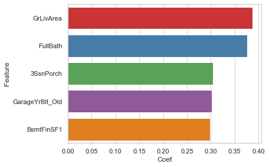

```python
plt.figure(figsize=(20,20))
plt.subplot(4,3,1)
sns.barplot(y = 'Feature', x='Coef', palette='Set1', data = top5)
plt.show()
```

**From the newly created model GrLivArea,FullBath,3SsnPorch,GarageYrBlt_Old,BsmtFinSF1 are the top five models when the top five features are dropped**  
**The model when top five are dropped also performs good with train and test accuracy**